# Beyond Default Plotly Graphics

Mastering Customization in R’s plotly for Interactive Graphics

Cheng Peng

West Chester University

# 1 Introduction

The plotly package in R transforms static ggplot2 graphics into interactive web-based visualizations with a single function call—ggplotly() . However, relying on default behaviors only scratches the surface of what’s possible. While plotly automatically handles tooltip generation, axis scaling, and hover information, production-grade applications and exploratory data analysis dashboards demand finer control. This guide explores advanced customization techniques across three critical dimensions: layout design, popup and hover information, and tooltip interactions. Each section provides actionable code examples that go beyond the defaults to create professional, user-centered interactive graphics.

# 2 Layout Design and Customization

## 2.1 Multi-Axis Layouts with Overlapping Traces

When visualizing variables measured on different scales—for instance, revenue in millions alongside percentage growth rates—a single y-axis creates misleading comparisons. plotly supports secondary y-axes through the yaxis and yaxis2 specifications within the layout() function.

To create a dual-axis plot, define the second axis using overlaying = “y” and position it on the opposite side with side = “right”:

```r
#library(plotly)

# Sample data
df <- data.frame(
  month = 1:12,
  revenue = c(5, 6, 7, 8, 9, 10, 11, 13, 15, 18, 22, 28),
  growth_pct = c(2.1, 2.5, 3.0, 3.8, 4.2, 4.5, 5.0, 5.5, 6.1, 6.8, 7.2, 8.0)
)

plot_ly() %>%
  add_trace(
    x = ~df$month, y = ~df$revenue, type = 'scatter', mode = 'lines+markers',
    name = 'Revenue (Millions)', yaxis = 'y'
  ) %>%
  add_trace(
    x = ~df$month, y = ~df$growth_pct, type = 'scatter', mode = 'lines+markers',
    name = 'Growth (%)', yaxis = 'y2'
  ) %>%
  layout(
    title = "Monthly Performance: Dual-Axis View",
    xaxis = list(title = "Month"),
    yaxis = list(title = "Revenue (Millions)", side = "left"),
    yaxis2 = list(
      title = "Growth (%)", overlaying = "y", side = "right",
      tickformat = ".1f%%"  # Format as percentage with one decimal
    ),
    legend = list(x = 0.02, y = 0.98)
  )
```

[interactive chart not shown]

The tickformat parameter accepts d3 formatting syntax—a critical detail for professional financial and scientific visualizations. Common formats include “.2f” (two decimal places), “$.2f” (currency), and “,.0f” (thousands separator with no decimals).

## 2.2 Subplot Arrangements and Unified Annotations

The subplot() function combines multiple plotly objects into a single figure . While combining plots is straightforward, maintaining consistent annotations across panels requires careful attention to axis sharing and title placement.

A common challenge involves sharing axes between subplots while preserving axis labels. Using shareX = TRUE and shareY = TRUE ensures consistent scaling, but axis titles may disappear . The solution involves defining titles only on the boundary subplots:

```r
# Create three related plots
p1 <- plot_ly(economics, x = ~date, y = ~uempmed, type = 'scatter', mode = 'lines') %>%
  layout(title = "Unemployment Duration", xaxis = list(title = ""), yaxis = list(title = "Weeks"))

p2 <- plot_ly(economics, x = ~date, y = ~unemploy, type = 'scatter', mode = 'lines') %>%
  layout(title = "Unemployment Count", xaxis = list(title = ""), yaxis = list(title = "Persons"))

p3 <- plot_ly(economics, x = ~date, y = ~pce, type = 'scatter', mode = 'lines') %>%
  layout(title = "Personal Consumption", xaxis = list(title = "Year"), yaxis = list(title = "Billions USD"))

# Combine with shared x-axis, custom heights
subplot(p1, p2, p3, nrows = 3, shareX = TRUE, titleY = TRUE, heights = c(0.3, 0.3, 0.4))
```

[interactive chart not shown]

The heights parameter accepts proportional values that sum to 1, allowing emphasis on particularly important subplots . For uniform layouts with multiple columns, use nrows and widths to control column proportions.

## 2.3 Dynamic Color Scales and Theme Integration

Static color assignments fail when data ranges change dynamically. plotly supports color interpolation through the colors parameter and the RColorBrewer palette system. For continuous data, use colorbar() to customize the legend:

```r
#library(viridisLite)

# Dynamic color mapping based on data values
set.seed(123)
df_color <- data.frame(
  x = rnorm(200),
  y = rnorm(200),
  value = runif(200, min = 0, max = 100)
)

plot_ly(
  df_color, x = ~x, y = ~y, type = 'scatter', mode = 'markers',
  marker = list(
    size = 8,
    color = ~value,
    colorscale = 'Viridis',  # Built-in perceptually uniform scale
    colorbar = list(
      title = "Intensity",
      tickformat = ".0f",
      ticks = "outside"
    ),
    showscale = TRUE
  )
) %>%
  layout(
    title = "Dynamic Color Mapping with Viridis Scale",
    plot_bgcolor = "#f8f9fa",  # Light gray background
    paper_bgcolor = "#ffffff"
  )
```

[interactive chart not shown]

For categorical data requiring brand or custom color schemes, define named color vectors:

```r
custom_colors <- c(
  "High" = "#d73027",
  "Medium" = "#fc8d59",
  "Low" = "#91bfdb"
)

plot_ly(mtcars, x = ~wt, y = ~mpg, color = ~factor(cyl),
        colors = c("#1b9e77", "#d95f02", "#7570b3"), type = 'scatter', mode = 'markers')
```

[interactive chart not shown]

# 3 User-defined Standalone Layout for plotly plot

```r
# Define a professional layout template
professional_theme <- function(p, title_text = NULL) {
  p %>%
    layout(
      title = list(text = title_text, font = list(size = 16, family = "Arial", color = "#2c3e50")),
      xaxis = list(
        title = list(font = list(size = 12), standoff = 10),
        gridcolor = "#e0e0e0",
        linecolor = "#cccccc",
        tickfont = list(size = 10),
        zeroline = FALSE
      ),
      yaxis = list(
        title = list(font = list(size = 12), standoff = 10),
        gridcolor = "#e0e0e0",
        linecolor = "#cccccc",
        tickfont = list(size = 10),
        zeroline = FALSE
      ),
      legend = list(
        orientation = 'h',
        yanchor = 'bottom',
        y = 1.02,
        xanchor = 'right',
        x = 1
      ),
      plot_bgcolor = "#ffffff",
      paper_bgcolor = "#ffffff",
      margin = list(t = 50, r = 30, b = 40, l = 50)
    )
}

# Apply to any plot
p_base <- plot_ly(mtcars, x = ~wt, y = ~mpg, type = 'scatter', mode = 'markers')
professional_theme(p_base, "Fuel Efficiency vs. Vehicle Weight")
```

[interactive chart not shown]

# 4 Popup and Hover Information Design

## 4.1 Custom Hover Templates with HTML Formatting

The default hover tooltip shows trace name, x value, and y value in plain text. The hovertemplate parameter overrides this completely, supporting HTML-like formatting for bold text, line breaks, and colored values. However, plotly restricts HTML in hovertemplate to `<b>, <i>, <br>`, and `<extra>` tags—complex tables require alternative approaches .

For rich single-line formatting:

```r
plot_ly(mtcars, x = ~wt, y = ~mpg, type = 'scatter', mode = 'markers',
        hovertemplate = paste(
          "<b>%{text}</b><br>",
          "Weight: <b>%{x:.2f}</b> tons<br>",
          "Economy: <b>%{y:.1f}</b> mpg<br>",
          "<extra></extra>"  # Removes the default trace name box
        ),
        text = ~rownames(mtcars)) %>%
  layout(title = "Custom Hover Template with Formatted Values")
```

[interactive chart not shown]

The `<extra></extra>` tag is essential—it suppresses the secondary information box that would otherwise display trace names. Without this, tooltips appear cluttered with redundant information.

## 4.2 Conditional Popup Content Based on Data Values

```r
#library(dplyr)

# Create conditional hover text based on mpg thresholds
mtcars_custom <- mtcars %>%
  mutate(
    efficiency_rating = case_when(
      mpg > 25 ~ "Excellent",
      mpg > 20 ~ "Good",
      mpg > 15 ~ "Average",
      TRUE ~ "Poor"
    ),
    custom_hover = case_when(
      mpg > 25 ~ paste0(
        "<b>", rownames(.), "</b> 🌟<br>",
        "Economy: ", round(mpg, 1), " mpg (Excellent)<br>",
        "Engine: ", cyl, " cylinders<br>",
        "⭐ Top efficiency rating"
      ),
      mpg < 15 ~ paste0(
        "<b>", rownames(.), "</b> ⚠️<br>",
        "Economy: ", round(mpg, 1), " mpg (Poor)<br>",
        "Engine: ", cyl, " cylinders<br>",
        "⚠️ Consider fuel-efficient alternatives"
      ),
      TRUE ~ paste0(
        "<b>", rownames(.), "</b><br>",
        "Economy: ", round(mpg, 1), " mpg<br>",
        "Engine: ", cyl, " cylinders"
      )
    )
  )

plot_ly(mtcars_custom, x = ~wt, y = ~mpg, type = 'scatter', mode = 'markers',
        hoverinfo = 'text',
        hovertext = ~custom_hover,
        marker = list(size = 10, color = ~mpg, colorscale = 'RdYlGn', showscale = TRUE)) %>%
  layout(title = "Conditional Hover Content Based on Efficiency Thresholds")
```

[interactive chart not shown]

This approach informs users immediately when data points fall into exceptional or concerning categories without requiring additional dashboard components.

## 4.3 Multi-Trace Hover Synchronization

When multiple traces share the same x-axis (e.g., time series from different metrics), comparing hover information requires synchronizing tooltips across traces. Set `hovermode = "x unified"` in the layout:

```r
# Time series data with multiple metrics
economics_long <- economics %>%
  select(date, pce, unemploy, uempmed) %>%
  tidyr::pivot_longer(cols = c(pce, unemploy, uempmed), names_to = "metric", values_to = "value")

plot_ly() %>%
  add_trace(data = filter(economics_long, metric == "pce"),
            x = ~date, y = ~value, name = "Personal Consumption", type = 'scatter', mode = 'lines',
            line = list(color = '#1f77b4')) %>%
  add_trace(data = filter(economics_long, metric == "unemploy"),
            x = ~date, y = ~value, name = "Unemployment", type = 'scatter', mode = 'lines',
            line = list(color = '#ff7f0e'), yaxis = "y2") %>%
  add_trace(data = filter(economics_long, metric == "uempmed"),
            x = ~date, y = ~value, name = "Unemployment Duration", type = 'scatter', mode = 'lines',
            line = list(color = '#2ca02c'), yaxis = "y3") %>%
  layout(
    title = "Synchronized Hover Across All Traces",
    hovermode = "x unified",  # Single tooltip shows all traces at cursor x-position
    xaxis = list(title = "Date"),
    yaxis = list(title = "PCE (Billions)", side = "left"),
    yaxis2 = list(title = "Unemployment Count", overlaying = "y", side = "right"),
    yaxis3 = list(title = "Duration (Weeks)", overlaying = "y", side = "right", position = 0.85)
  )
```

[interactive chart not shown]

The “x unified” hover mode displays a single tooltip containing data from all traces at the current x-position, dramatically improving cross-trace comparison.

# 5 Tooltip Design and Advanced Interactions

## 5.1 Click-Triggered Information Panels with Reactive Annotations

Beyond hover-based tooltips, plotly supports click events that trigger dynamic updates. In Shiny applications, event_data(“plotly_click”) captures click information and drives reactive outputs :

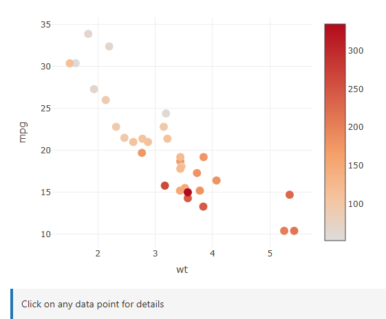

```r
library(shiny)

ui <- fluidPage(
  tags$head(tags$style(HTML("
    .info-panel {
      background: #f5f5f5;
      border-left: 4px solid #1f77b4;
      padding: 12px;
      margin-top: 20px;
      font-family: 'Segoe UI', sans-serif;
    }
  "))),
  plotlyOutput("scatterplot"),
  uiOutput("click_info")
)

server <- function(input, output) {
  output$scatterplot <- renderPlotly({
    plot_ly(mtcars, x = ~wt, y = ~mpg, type = 'scatter', mode = 'markers',
            text = ~paste("Car:", rownames(mtcars)),
            hovertemplate = paste("<b>%{text}</b><br>",
                                  "Weight: %{x:.2f}<br>",
                                  "MPG: %{y:.1f}<br>",
                                  "<extra></extra>"),
            marker = list(size = 12, color = ~hp, colorscale = 'Plasma', showscale = TRUE))
  })

  output$click_info <- renderUI({
    d <- event_data("plotly_click")
    if (is.null(d)) {
      return(div(class = "info-panel", "Click on any data point for details"))
    }

    car_name <- rownames(mtcars)[which.min(abs(mtcars$wt - d$x) + abs(mtcars$mpg - d$y))]
    car_data <- mtcars[car_name, ]

    div(class = "info-panel",
        h4("Selected Vehicle: ", strong(car_name)),
        tags$table(
          tags$tr(tags$td("Weight (1000 lbs):"), tags$td(strong(round(car_data$wt, 2)))),
          tags$tr(tags$td("Fuel Economy (MPG):"), tags$td(strong(round(car_data$mpg, 1)))),
          tags$tr(tags$td("Horsepower:"), tags$td(strong(car_data$hp))),
          tags$tr(tags$td("Cylinders:"), tags$td(strong(car_data$cyl))),
          tags$tr(tags$td("Transmission:"), tags$td(strong(ifelse(car_data$am == 1, "Manual", "Automatic"))))
        )
    )
  })
}

shinyApp(ui, server)
```

The event_data() function captures clicks, hovers, selections, and brushing events . For plots with multiple subplots, use the source parameter in both plot_ly() and event_data() to distinguish between them.

## 5.2 Tooltip Animation and Delayed Loading Indicators

For heavy datasets or plots requiring external data fetching, loading indicators improve perceived performance. While plotly doesn’t natively support animated tooltip loading, the htmlwidgets::onRender() function allows custom JavaScript execution :

```r
#library(htmlwidgets)

plot_with_loading <- plot_ly(mtcars[1:10, ], x = ~wt, y = ~mpg, type = 'scatter', mode = 'markers',
                             marker = list(size = 15)) %>%
  layout(title = "Hover shows loading simulation") %>%
  onRender("
    function(el, x) {
      var originalHover = el.data.hoverinfo;

      el.on('plotly_hover', function(e) {
        var point = e.points[0];
        var hoverDiv = document.createElement('div');
        hoverDiv.id = 'custom-hover-' + point.pointNumber;
        hoverDiv.style.position = 'absolute';
        hoverDiv.style.backgroundColor = 'rgba(0,0,0,0.8)';
        hoverDiv.style.color = 'white';
        hoverDiv.style.padding = '8px';
        hoverDiv.style.borderRadius = '4px';
        hoverDiv.style.zIndex = '1000';
        hoverDiv.innerHTML = 'Loading data... <div class=\"spinner\"></div>';
        document.body.appendChild(hoverDiv);

        setTimeout(function() {
          hoverDiv.innerHTML = '<b>' + x.data[0].text[point.pointNumber] + '</b><br>' +
                               'Weight: ' + point.x.toFixed(2) + '<br>' +
                               'MPG: ' + point.y.toFixed(1);
          hoverDiv.style.left = (e.event.pageX + 10) + 'px';
          hoverDiv.style.top = (e.event.pageY + 10) + 'px';
        }, 300);
      });

      el.on('plotly_unhover', function() {
        document.querySelectorAll('[id^=\"custom-hover-\"]').forEach(function(el) {
          el.remove();
        });
      });
    }
  ")

plot_with_loading
```

[interactive chart not shown]

This technique creates custom tooltips with loading states, useful when hover triggers expensive computations or API calls.

# 6 Context-Aware Tooltips with External Data Linking

Perhaps the most powerful customization involves completely replacing plotly’s default tooltip system with custom HTML elements that display formatted tables, images, or linked data . This approach disables native tooltips via hoverlabel = list(enabled = FALSE) and implements custom JavaScript rendering:

```r
#library(htmlwidgets)
#library(jsonlite)

# Create data with external lookup information
cars_enhanced <- mtcars[1:15, ]
cars_enhanced$car_name <- rownames(cars_enhanced)
cars_enhanced$description <- paste("The", rownames(cars_enhanced), "featured",
                                   ifelse(cars_enhanced$cyl > 6, "a powerful V8 engine",
                                          "efficient cylinder configuration"))

js_tooltip_code <- paste0('
function(el, x) {
  var data = ', toJSON(cars_enhanced), ';

  var tooltip = document.createElement("div");
  tooltip.style.display = "none";
  tooltip.style.position = "absolute";
  tooltip.style.backgroundColor = "white";
  tooltip.style.border = "2px solid #1f77b4";
  tooltip.style.borderRadius = "8px";
  tooltip.style.padding = "12px";
  tooltip.style.zIndex = "1000";
  tooltip.style.boxShadow = "3px 3px 12px rgba(0,0,0,0.25)";
  tooltip.style.fontFamily = "Arial, sans-serif";
  tooltip.style.maxWidth = "300px";
  document.body.appendChild(tooltip);

  el.on("plotly_hover", function(e) {
    var pt = e.points[0];
    var idx = pt.pointNumber;
    var car = data[idx];

    tooltip.innerHTML = `
      <div style="font-weight:bold; font-size:14px; margin-bottom:8px; color:#1f77b4;">
        🚗 ${car.car_name}
      </div>
      <div style="font-size:12px; margin-bottom:8px;">${car.description}</div>
      <table style="width:100%; font-size:11px; border-collapse:collapse;">
        <tr><td style="padding:4px; font-weight:bold;">Weight:</td>
          <td style="padding:4px;">${car.wt.toFixed(2)} (1000 lbs)</td></tr>
        <tr><td style="padding:4px; font-weight:bold;">MPG:</td>
          <td style="padding:4px;">${car.mpg.toFixed(1)}</td></tr>
        <tr><td style="padding:4px; font-weight:bold;">Horsepower:</td>
          <td style="padding:4px;">${car.hp}</td></tr>
        <tr><td style="padding:4px; font-weight:bold;">Cylinders:</td>
          <td style="padding:4px;">${car.cyl}</td></tr>
      </table>
    `;

    tooltip.style.display = "block";
    tooltip.style.left = (e.event.pageX + 15) + "px";
    tooltip.style.top = (e.event.pageY + 15) + "px";
  });

  el.on("plotly_unhover", function() {
    tooltip.style.display = "none";
  });
}
')

plot_ly(cars_enhanced, x = ~wt, y = ~mpg, type = "scatter", mode = "markers",
        marker = list(size = 12, color = ~hp, colorscale = "Viridis")) %>%
  layout(hoverlabel = list(enabled = FALSE),  # Critical: disable defaults
         title = "Custom Table Tooltips with External Data") %>%
  onRender(js_tooltip_code)
```

[interactive chart not shown]

This technique enables complete HTML/CSS customization—tables, images, formatted text, and even interactive elements within tooltips. The external data linking allows tooltip content to reference information not explicitly encoded in the plot’s traces, enabling richer contextual information without cluttering the visualization itself.

The key insight from this pattern is that plotly hover events provide point indices that can index into any R data frame, creating a bridge between the visual representation and the full underlying dataset. This separation of concerns—visual marks in the plot, rich content in tooltips—produces clean, maintainable, and highly informative interactive graphics .

# 7 Key Takeaways

**Layout Design**: Master multi-axis configurations, subplot arrangements, and dynamic color scales for professional-grade visualizations.

**Popup Engineering**: Create context-rich hover experiences with HTML formatting, conditional content, and synchronized cross-trace information.

**Tooltip Excellence**: Implement advanced tooltip features including animations, external data enrichment, and interactive click events for enhanced user engagement.

The combination of these techniques allows you to create visualizations that not only present data but tell compelling stories through interactive exploration.

# 8 References

Sievert, C. (2020). Interactive Web-Based Data Visualization with R, plotly, and shiny. Chapman and Hall/CRC.

Plotly Technologies Inc. (2025). event_data: Access plotly user input event data in shiny.

Stack Overflow. (2025). How to Display a Data Frame as Hover Text in Plotly for R?

Plotly Community Forum. (2025). Slow update of plot even with client side callback.

RDRR.io. (2025). subplot: Combine multiple plotly objects.